# Copenhagen, Denmark

ESM 327 Homework #1 - Climate Trends

Keene Morrow

4/15/2020

#### Background

Copenhagen is the capital of Denmark. Located on the east side of Denmark’s largest island, Zealand, Copenhagen is separated from Sweden by the Øresund. In the author’s experience, the city is dominated by paved areas but has numerous parks and easy access to the harbor for recreation. Topographically, the city, like the rest of Denmark, is remarkably flat.

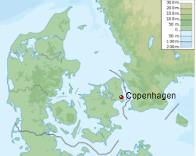

*Copenhagen’s location within Denmark. Source: Wikipedia*

As a coastal city, Copenhagen is particularly vulnerable to sea level rise and coastal flooding. Local fisheries will be impacted by the shift of marine species towards higher latitudes. Changes in precipitation and the exacerbation of extreme weather may impact agriculture in the area, both positively (increased cereal yields, possibility of wine grape cultivation) and negatively (increased pest activity, impact of heat on livestock). Extreme heat and cold are expected to have significant socioeconomic and health effects. (IPCC 2014)

#### Data

Data from the Danish Meterological Institute (Danmarks Meteorologiske Institut) meteorological station at Landbohøjskolen, Københavns Universitet (Land High School, University of Copenhagen) will be used to assess the climate trends from January 1, 1874 and December 31, 2019. The precipitation data contained 44834 daily observations. No data was available for 272 days within the observation period. The temeprature data contained 106557 daily high and low observations. No data was available for 95 days within the observation period.

#### Analysis

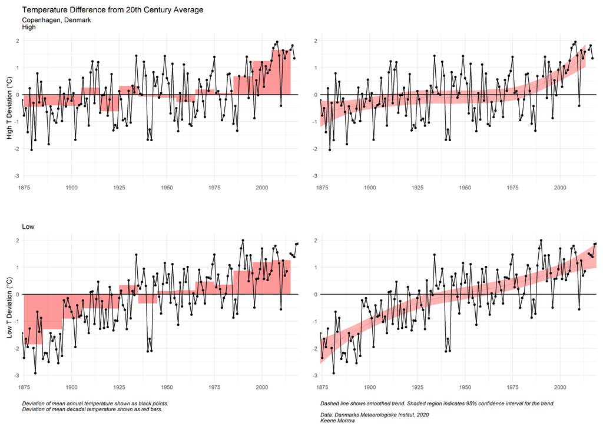

*Figure 1*

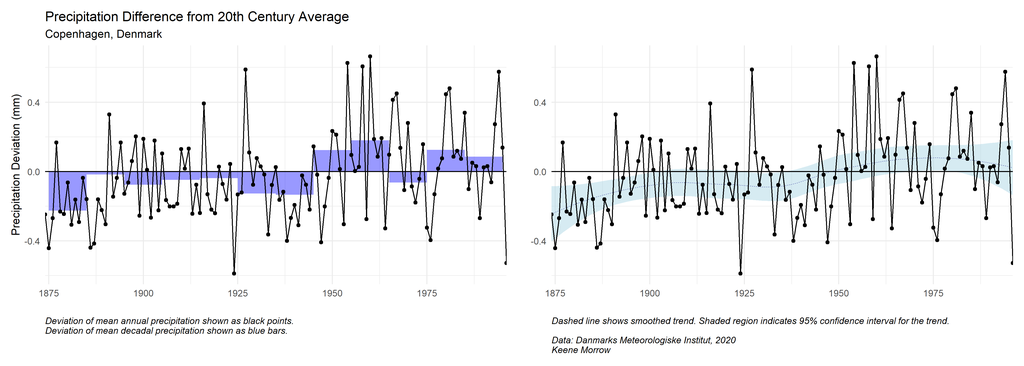

*Figure 2*

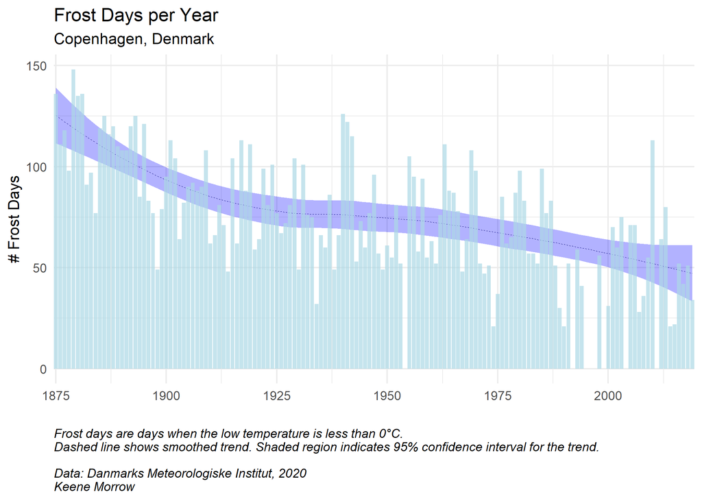

*Figure 3*

An examination of changes in seasonal mean high temperature show that the greatest impacts to temperature can be seen during the winter, spring, and fall. Lows, by contrast, follow similar upward trends regardless of season. (Figure 4) This suggests that extreme heat may not be an immediate concern of those raising livestock. The concavity of the trend in the hottest day of the year suggests that extreme heat may become of increasing concern in the future. (Figure 5)

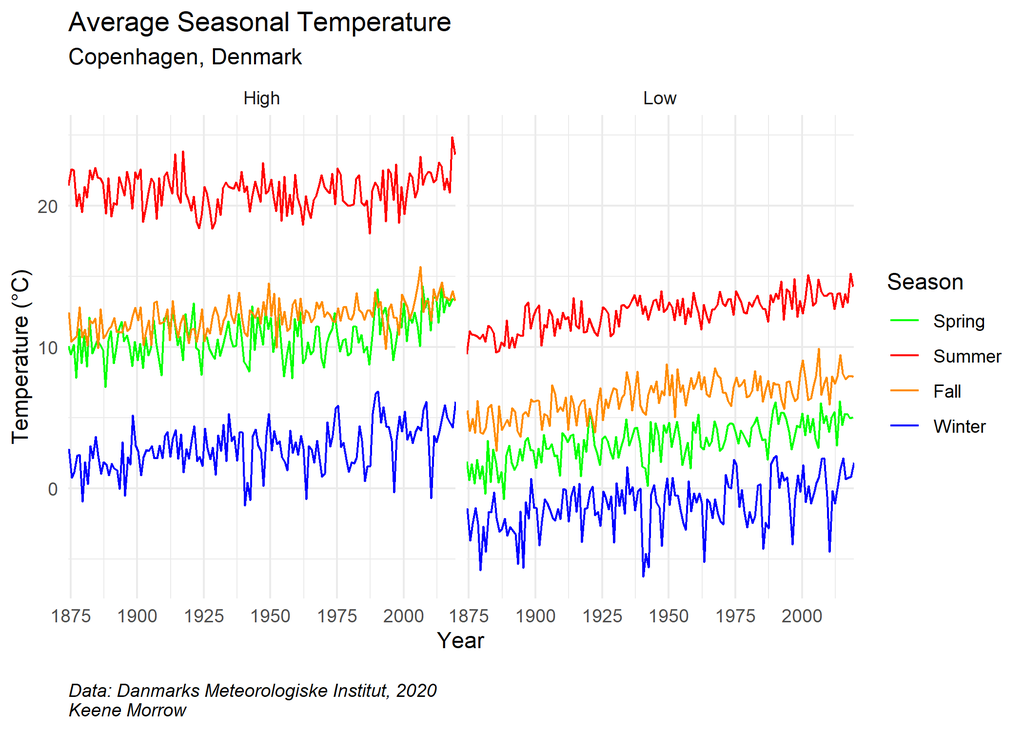

*Figure 4*

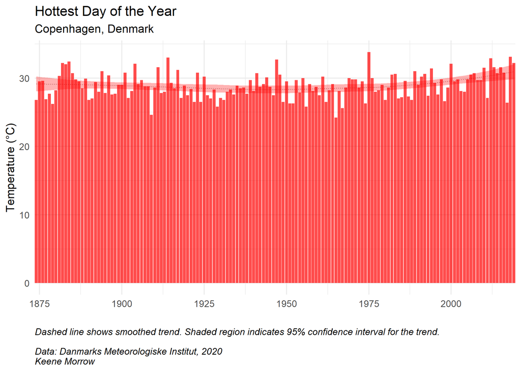

*Figure 5*

Monthly mean temperatures (Figure 6) show the most deviation from historic records in winter months, particularly in lows. Like other metrics, monthly mean lows have seen more consistent elevation than highs.

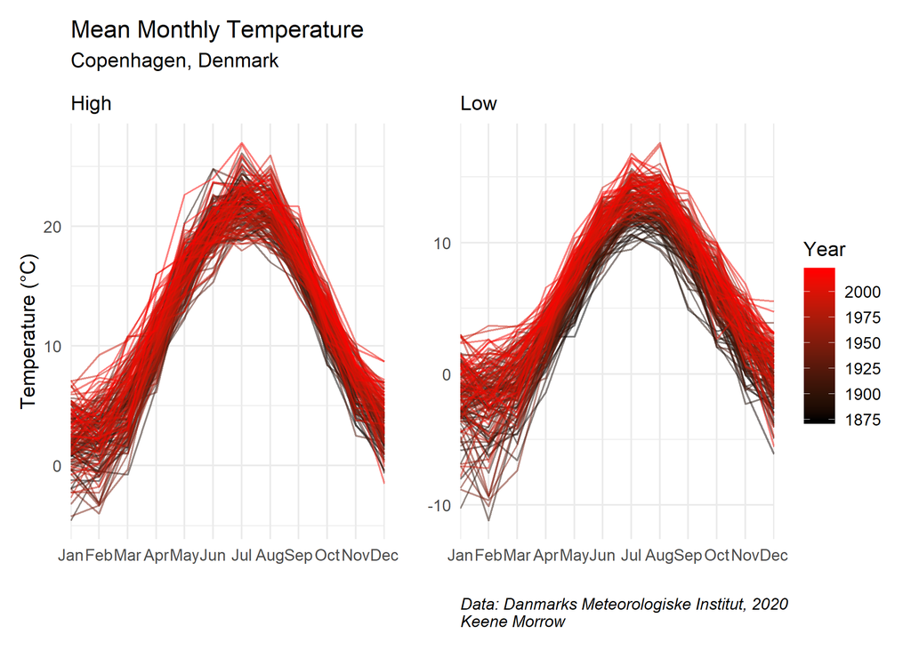

*Figure 6*

Seasonal and monthly trends in precipitation are difficult to discern. There may be a slight increase in spring precipitation. Other trends could not be discerned. (Figures 7 & 8)

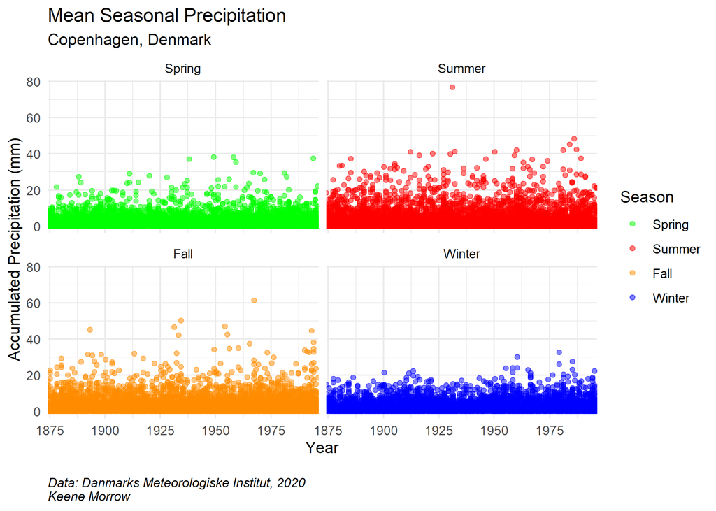

*Figure 7*

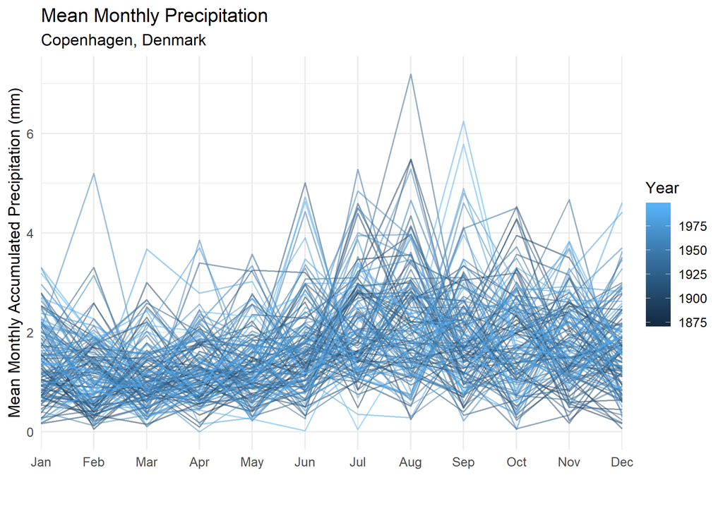

*Figure 8*

#### Conclusion

Copenhagen has historically benefited from a mild maritime climate. Ocean warming may exacerbate existing upward trends in temperature, especially lows. There has been little discernable change in precipitation to date, but continued disruption to temperatures may force more extreme increases in precipitation. These trends may significantly impact agricultural systems in Denmark as a whole.

#### References

IPCC, 2014. “AR5 Climate Change 2014: Impacts, Adaptation, and Vulnerability, Part B: Regional Aspects.” https://www.ipcc.ch/report/ar5/wg2/

Cappelen, John. 2020. “DMI Report 20-02 Denmark - DMI Historical Climate Data Collection 1768-2019.” Danmarks Meteorologiske Institut. https://www.dmi.dk/fileadmin/user_upload/Rapporter/TR/2020/DMIRep20-02.pdf